# map501_F416781

##e: Poisson model with random effect (poisson_mod2)

```r
# Rescaling variables
df_pitchers <- df_pitchers %>%
  mutate(across(c(innings, weight, height), scale))

# Remove sparse levels or rare categories, if needed
df_pitchers <- df_pitchers %>%
  filter(throws != "S")

# Fit the model
poisson_mod2 <- glmer(SHO ~ innings + weight + height + throws + (1 | teamID),
                      data = df_pitchers,
                      family = "poisson",
                      control = glmerControl(optimizer = "bobyqa"))

# Check the model summary
summary(poisson_mod2)
```

```
## Generalized linear mixed model fit by maximum likelihood (Laplace
##   Approximation) [glmerMod]
##  Family: poisson  ( log )
## Formula: SHO ~ innings + weight + height + throws + (1 | teamID)
##    Data: df_pitchers
## Control: glmerControl(optimizer = "bobyqa")
##
##      AIC      BIC   logLik deviance df.resid
##  17910.6  17960.6  -8949.3  17898.6    30999
##
## Scaled residuals:
##     Min      1Q  Median      3Q     Max
## -3.2044 -0.2237 -0.1505 -0.1164 11.7961
##
## Random effects:
##  Groups Name        Variance Std.Dev.
##  teamID (Intercept) 0.04886  0.221
## Number of obs: 31005, groups:  teamID, 35
##
## Fixed effects:
##             Estimate Std. Error z value Pr(>|z|)
## (Intercept) -3.06162    0.05196 -58.917  < 2e-16 ***
## innings      1.32384    0.01232 107.433  < 2e-16 ***
## weight      -0.19895    0.01858 -10.708  < 2e-16 ***
## height       0.12987    0.01718   7.559 4.07e-14 ***
## throwsR     -0.11827    0.03024  -3.911 9.19e-05 ***
## ---
## Signif. codes:  0 '***' 0.001 '**' 0.01 '*' 0.05 '.' 0.1 ' ' 1
##
## Correlation of Fixed Effects:
##         (Intr) innngs weight height
## innings -0.445
## weight   0.020  0.136
## height   0.003 -0.077 -0.544
## throwsR -0.392  0.001  0.012 -0.119
```

Interpretation From the model results, it appears that teamID (the random effect) does not play a very significant role as a predictor. Here is why:

1. Variance of the Random Effect The variance of the random effect for teamID is 0.04886, and the standard deviation is 0.221. These values are relatively small, indicating that the variation in SHO (shutouts) due to differences between teams is minimal compared to the overall variability in the data.
2. Random Effects vs Fixed Effects The fixed effects (such as innings, weight, height, and throws) have much larger z-values and highly significant p-values (all < 0.001). This indicates that these variables explain a substantial portion of the variability in SHO. The small variance of the teamID random effect suggests that the additional grouping structure provided by teamID is not contributing much explanatory power to the model.

##f: Scale-location plot

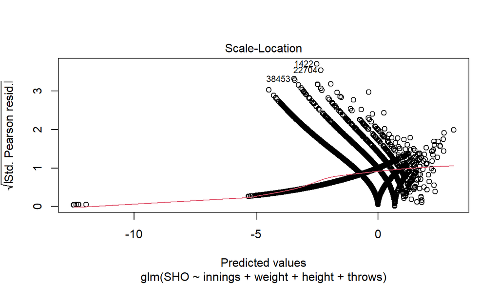

```r
# Scale-location plot for poisson_mod1
plot(poisson_mod1, which = 3)
```

```r
# Observation:
# The scale-location plot should show no clear pattern if model assumptions hold.
# Deviations suggest issues like heteroscedasticity.
```

##g: Effects of throwing hand, height, and weight

```r
# Ensure 'throws' is a factor with the correct levels
df_pitchers$throws <- factor(df_pitchers$throws, levels = c("R", "L"))

# Refit the Poisson model
poisson_mod1 <- glmer(SHO ~ innings + weight + height + throws + (1 | teamID),
                      data = df_pitchers,
                      family = "poisson",
                      control = glmerControl(optimizer = "bobyqa"))

# Extract coefficients
coef_summary <- summary(poisson_mod1)$coefficients

# Check the row names of coefficients
rownames(coef_summary)

# Calculate the effects
exp_coef_throws <- exp(coef_summary["throwsL", "Estimate"]) # Adjust if necessary
exp_coef_height <- exp(coef_summary["height", "Estimate"])
exp_coef_weight <- exp(coef_summary["weight", "Estimate"])

# Output the effects
list(
  "Effect of Left Handed" = exp_coef_throws,
  "Effect of Height" = exp_coef_height,
  "Effect of Weight" = exp_coef_weight
)
```

```
## [1] "(Intercept)" "innings"     "weight"      "height"      "throwsL"
## $`Effect of Left Handed`
## [1] 1.125546
##
## $`Effect of Height`
## [1] 1.138685
##
## $`Effect of Weight`
## [1] 0.8195916
```